# MODELAGEM PARA DADOS DE CONTAGEM

Hillnara de Paiva e João Vitor Andrade

# MODELAGEM PARA DADOS DE CONTAGEM

## DESCRIÇÃO DO PROBLEMA

Os dados estão relacionados as postagem publicadas durante o ano de 2014 na página do Facebook. Este conjunto de dados contém 500 observações e 7 variáveis, são ela:

**PPDS:** Postagem por dia da semana

**ATP:** Alcance total da postagem

**TVP:** Total de visualizações da postagem

**UE:** Usuários engajados

**CP:** Consumidores de postagem

**PEP:** Pessoas ao longo da vida que gostaram do seu perfil e se envolveram com o sua postagem

**IT:** Interações totais

## RETIRADO DO SITE:

UCI - Machine Learning Repository https://archive.ics.uci.edu/ml/datasets/CSM+%28Conventional+and+Social+Media+Movies%29+Dataset+2014+and+2015

### PACOTES

```r
library(GLMsData) # Dataset MLG
library(ISLR)     # Dataset livro: introduction a statistical learning
library(MASS)     # Modelos residuais
library(pscl)     # Calcular pseudo R2
library(qqplotr)  # Gráfico
library(metan)
library(dbplyr)
library(dplyr)
library(ggplot2)
library(car)
library(AER)
library(lme4)
library(hnp)
library(knitr)
library(rsq)
```

### BANCO DE DADOS

```r
library(readxl)
dados <- read_excel("C:/Users/hilln/OneDrive/Área de Trabalho/MODELOS LINEARES GENERALIZADOS/UNIDADE 1/Apresentação1/Facebook.xls")
View(dados)
```

### OBJETIVO

Análisar o comportamento de uma variável dependente (Interações totais), em função da variáveis preditoras.

### GRÁFICO DE CORRELAÇÃO

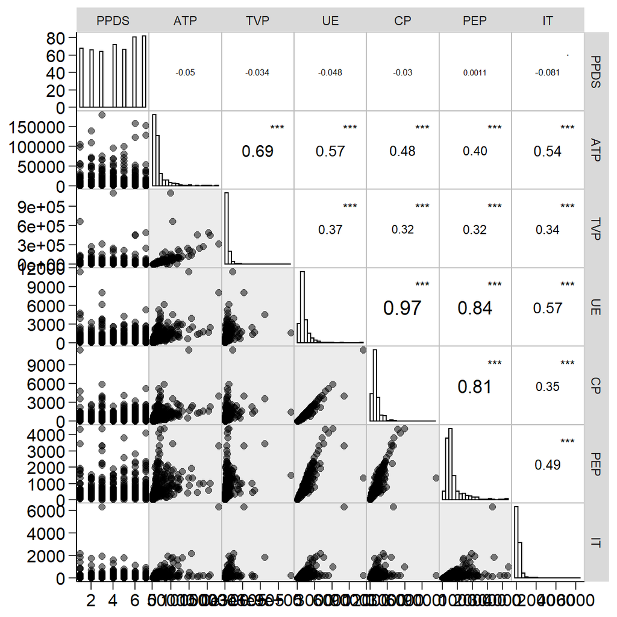

```r
attach(dados)
dados %>%
  corr_plot(PPDS, ATP, TVP, UE, CP, PEP,IT,
            shape.point = 19,
            size.point = 2,
            alpha.point = 0.5,
            alpha.diag = 0,
            pan.spacing = 0,
            col.sign = "gray",
            alpha.sign = 0.3,
            axis.labels = TRUE,
            progress = FALSE)
```

### MEDIDAS DESCRITIVAS

```r
kable(summary(dados))
```

|  | PPDS | ATP | TVP | UE | CP | PEP | IT |
| --- | --- | --- | --- | --- | --- | --- | --- |
|  | Min. :1.00 | Min. : 238 | Min. : 570 | Min. : 9.0 | Min. : 9.0 | Min. : 9.0 | Min. : 0.0 |
|  | 1st Qu.:2.00 | 1st Qu.: 3315 | 1st Qu.: 5695 | 1st Qu.: 393.8 | 1st Qu.: 332.5 | 1st Qu.: 291.0 | 1st Qu.: 71.0 |
|  | Median :4.00 | Median : 5281 | Median : 9051 | Median : 625.5 | Median : 551.5 | Median : 412.0 | Median : 123.5 |
|  | Mean :4.15 | Mean : 13903 | Mean : 29586 | Mean : 920.3 | Mean : 798.8 | Mean : 610.0 | Mean : 212.1 |
|  | 3rd Qu.:6.00 | 3rd Qu.: 13168 | 3rd Qu.: 22086 | 3rd Qu.: 1062.0 | 3rd Qu.: 955.5 | 3rd Qu.: 656.2 | 3rd Qu.: 228.5 |
|  | Max. :7.00 | Max. :180480 | Max. :1110282 | Max. :11452.0 | Max. :11328.0 | Max. :4376.0 | Max. :6334.0 |

### VARIÁVEL RESPOSTA

#### HISTOGRAMA

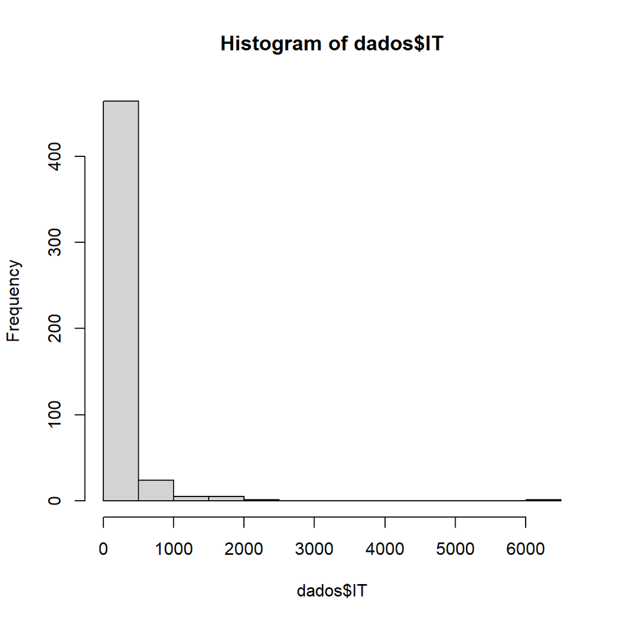

```r
hist(dados$IT)
```

- Os dados se concentram entorno de 0 e 1000
- Uma distribuição assimetria positiva

#### GRÁFICO

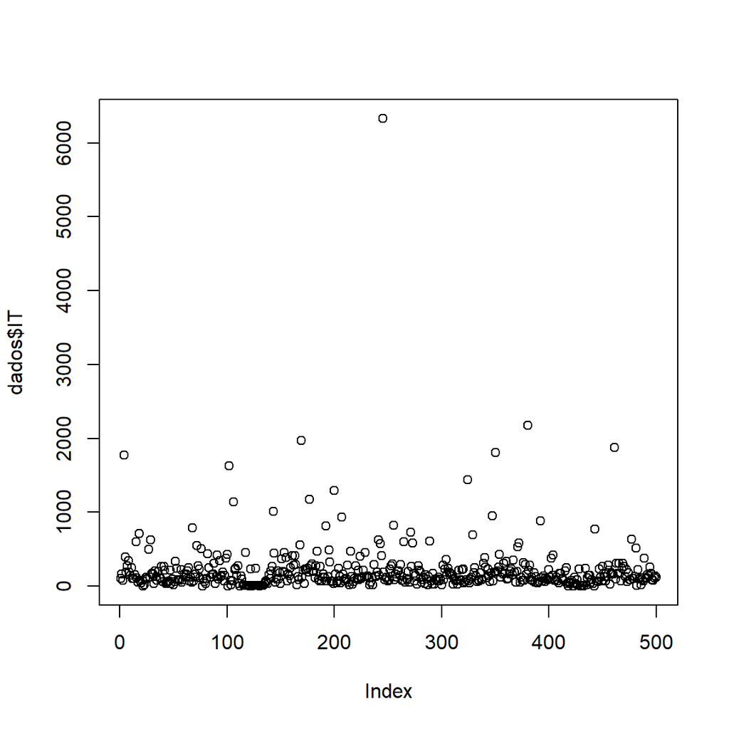

```r
plot(dados$IT)
```

- Gráfico de disperção

### MEDIA E DESVIO PADRÃO

```r
mean(dados$IT)
```

```
## [1] 212.12
```

```r
sd(dados$IT)
```

```
## [1] 380.2331
```

#### BOX PLOT

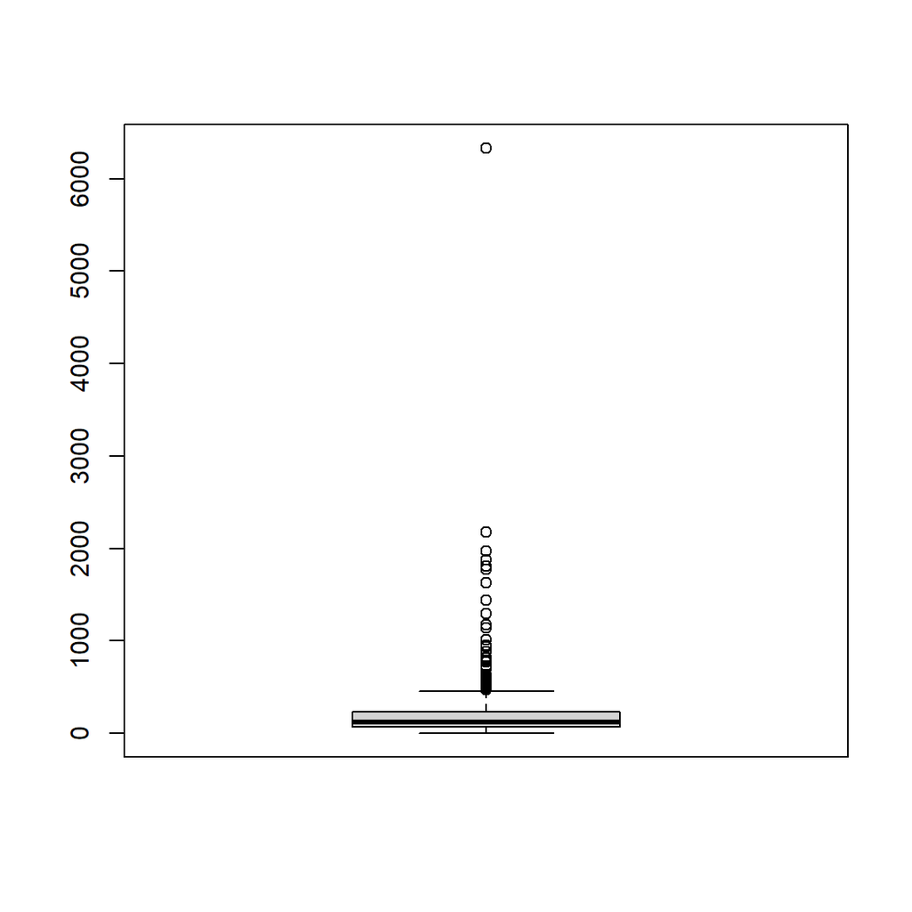

```r
boxplot(dados$IT)
```

- Os dados estão aglomerados, dado pelo intervalo interquartilíco (tamanho da caixa)
- Dados são assimétricos positivos, pois a linha da mediana está proxima ao primeiro quartil.
- Mediana menor que 500
- Presença de Outlier, indicado pelos valores discrepantes.

# METODOLOGIA UTILIZADA

## MODELO POISSON

### AJUSTE DO MODELO PELA FUNÇÃO glm()

##### MODELO 1

```r
mod = glm( formula = IT ~ PPDS + ATP + TVP + UE + CP + PEP , data=dados,
           family=poisson(link="log"), control=list(trace=TRUE))
```

```
## Deviance = 54120.03 Iterations - 1
## Deviance = 47618.82 Iterations - 2
## Deviance = 47501.33 Iterations - 3
## Deviance = 47501.21 Iterations - 4
## Deviance = 47501.21 Iterations - 5
```

```r
summary(mod)
```

```
##
## Call:
## glm(formula = IT ~ PPDS + ATP + TVP + UE + CP + PEP, family = poisson(link = "log"),
##     data = dados, control = list(trace = TRUE))
##
## Deviance Residuals:
##     Min       1Q   Median       3Q      Max
## -36.390   -7.372   -2.987    3.731   43.110
##
## Coefficients:
##               Estimate Std. Error z value Pr(>|z|)
## (Intercept)  4.925e+00  7.988e-03 616.566   <2e-16 ***
## PPDS        -3.028e-02  1.597e-03 -18.966   <2e-16 ***
## ATP          7.361e-06  1.887e-07  39.022   <2e-16 ***
## TVP         -8.450e-08  3.593e-08  -2.352   0.0187 *
## UE           4.439e-04  7.411e-06  59.904   <2e-16 ***
## CP          -9.603e-04  1.106e-05 -86.807   <2e-16 ***
## PEP          9.982e-04  1.309e-05  76.250   <2e-16 ***
## ---
## Signif. codes:  0 '***' 0.001 '**' 0.01 '*' 0.05 '.' 0.1 ' ' 1
##
## (Dispersion parameter for poisson family taken to be 1)
##
##     Null deviance: 133997  on 499  degrees of freedom
## Residual deviance:  47501  on 493  degrees of freedom
## AIC: 50790
##
## Number of Fisher Scoring iterations: 5
```

### R2

```r
pR2(mod)
```

```
## fitting null model for pseudo-r2
## Deviance = 186724.3 Iterations - 1
## Deviance = 136978.6 Iterations - 2
## Deviance = 134014.2 Iterations - 3
## Deviance = 133997.3 Iterations - 4
## Deviance = 133997.3 Iterations - 5
```

```
##           llh       llhNull            G2      McFadden          r2ML
## -2.538811e+04 -6.863614e+04  8.649605e+04  6.301057e-01  1.000000e+00
##          r2CU
##  1.000000e+00
```

### ANÁLISE DE RESÍDUO

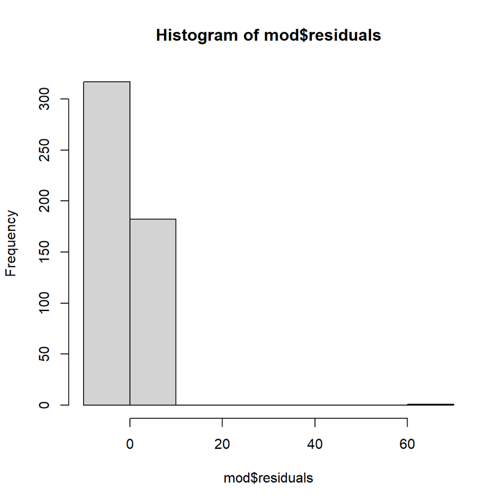

```r
hist( mod$residuals )
```

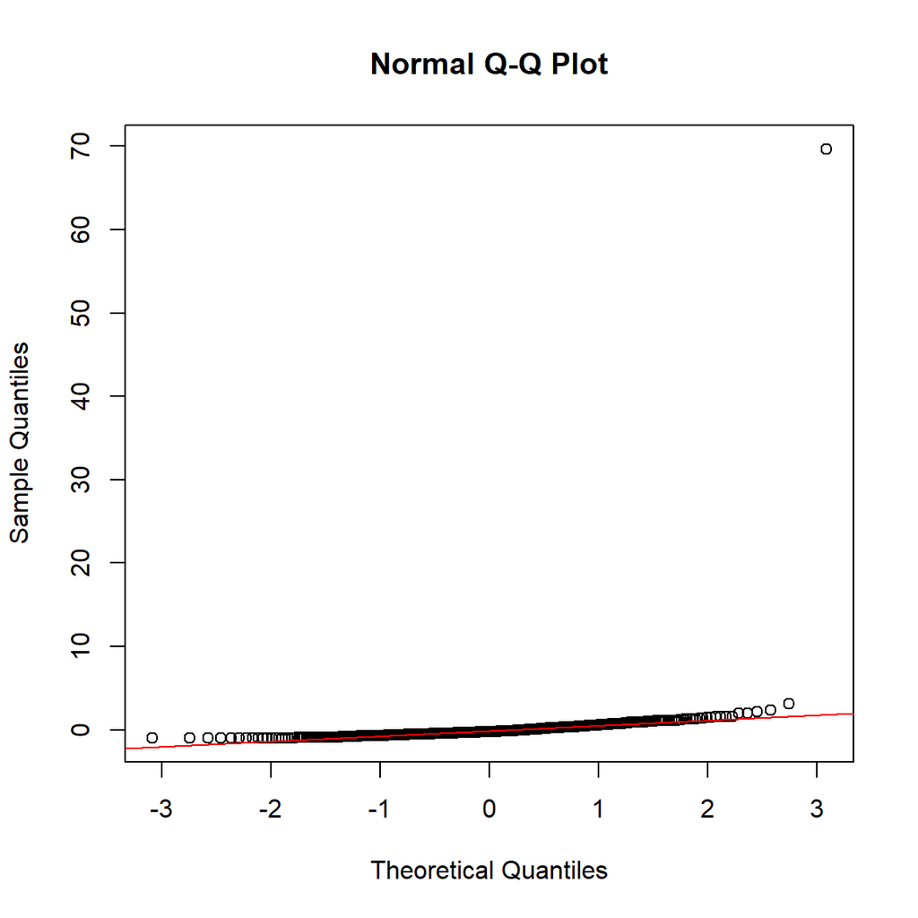

```r
qqnorm(mod$residuals)
qqline( mod$residuals, col = 'red' )
```

```r
shapiro.test( mod$residuals )
```

```
##
##  Shapiro-Wilk normality test
##
## data:  mod$residuals
## W = 0.11137, p-value < 2.2e-16
```

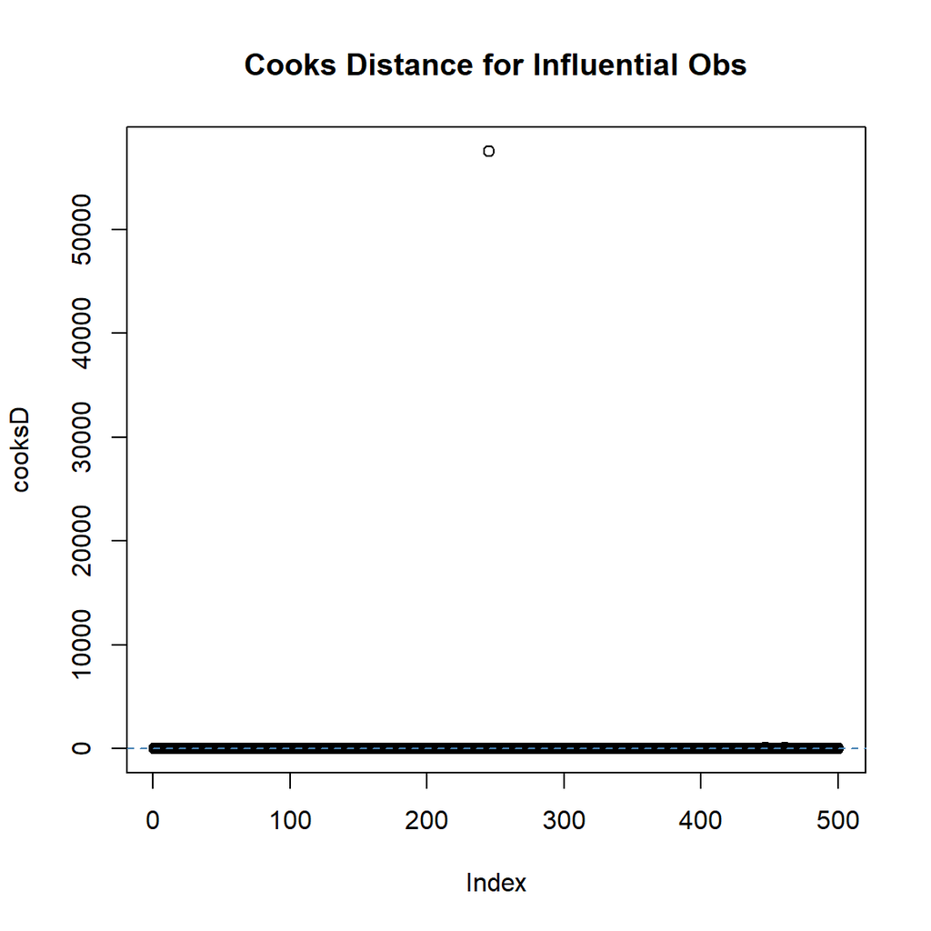

```r
cooksD = cooks.distance(mod)
n <- nrow(dados)
plot(cooksD, main = "Cooks Distance for Influential Obs")

abline(h = 4/n, lty = 2, col = "steelblue") # Adicionar linha de corte
```

# REMOVENDO DADOS INFLUENTES

## NOVO AJUSTE COM DADOS SEM PONTOS INFLUENTES

#### MODELO 2

```r
mod2 = glm( formula = IT ~ PPDS + ATP + UE + CP + PEP , data = dados_new ,
           family = poisson(link = 'log'), control=list(trace=TRUE))
```

```
## Deviance = 506.972 Iterations - 1
## Deviance = 503.5863 Iterations - 2
## Deviance = 503.5861 Iterations - 3
## Deviance = 503.5861 Iterations - 4
```

```r
summary(mod2)
```

```
##
## Call:
## glm(formula = IT ~ PPDS + ATP + UE + CP + PEP, family = poisson(link = "log"),
##     data = dados_new, control = list(trace = TRUE))
##
## Deviance Residuals:
##     Min       1Q   Median       3Q      Max
## -4.1236  -1.4443  -0.3767   1.1817   4.2873
##
## Coefficients:
##               Estimate Std. Error z value Pr(>|z|)
## (Intercept)  4.454e+00  3.078e-02 144.722  < 2e-16 ***
## PPDS        -2.324e-02  3.948e-03  -5.886 3.96e-09 ***
## ATP          6.543e-07  5.832e-07   1.122    0.262
## UE           5.806e-03  3.139e-04  18.494  < 2e-16 ***
## CP          -5.871e-03  2.892e-04 -20.297  < 2e-16 ***
## PEP          4.563e-04  6.066e-05   7.522 5.39e-14 ***
## ---
## Signif. codes:  0 '***' 0.001 '**' 0.01 '*' 0.05 '.' 0.1 ' ' 1
##
## (Dispersion parameter for poisson family taken to be 1)
##
##     Null deviance: 1822.15  on 144  degrees of freedom
## Residual deviance:  503.59  on 139  degrees of freedom
## AIC: 1497.6
##
## Number of Fisher Scoring iterations: 4
```

R2

```r
pR2(mod2)
```

```
## fitting null model for pseudo-r2
## Deviance = 1862.134 Iterations - 1
## Deviance = 1822.171 Iterations - 2
## Deviance = 1822.153 Iterations - 3
## Deviance = 1822.153 Iterations - 4
```

```
##           llh       llhNull            G2      McFadden          r2ML
##  -742.7891829 -1402.0725975  1318.5668293     0.4702206     0.9998876
##          r2CU
##     0.9998876
```

## ANALISE DE RESIDUO

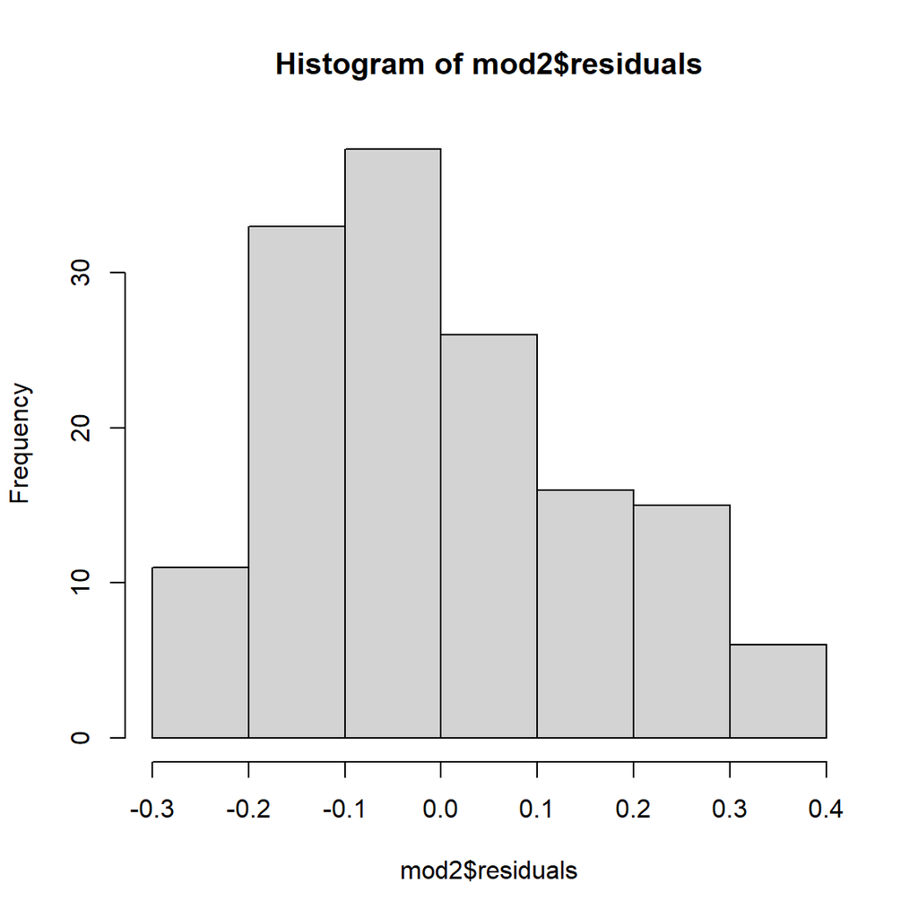

```r
hist( mod2$residuals )
```

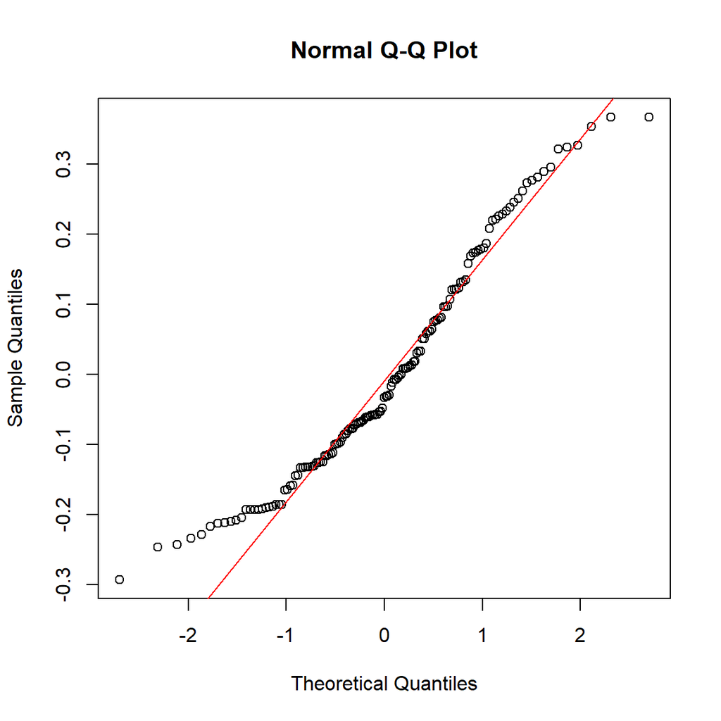

```r
qqnorm(mod2$residuals)
qqline( mod2$residuals, col = 'red' )
```

```r
shapiro.test( mod2$residuals )
```

```
##
##  Shapiro-Wilk normality test
##
## data:  mod2$residuals
## W = 0.95547, p-value = 0.0001276
```

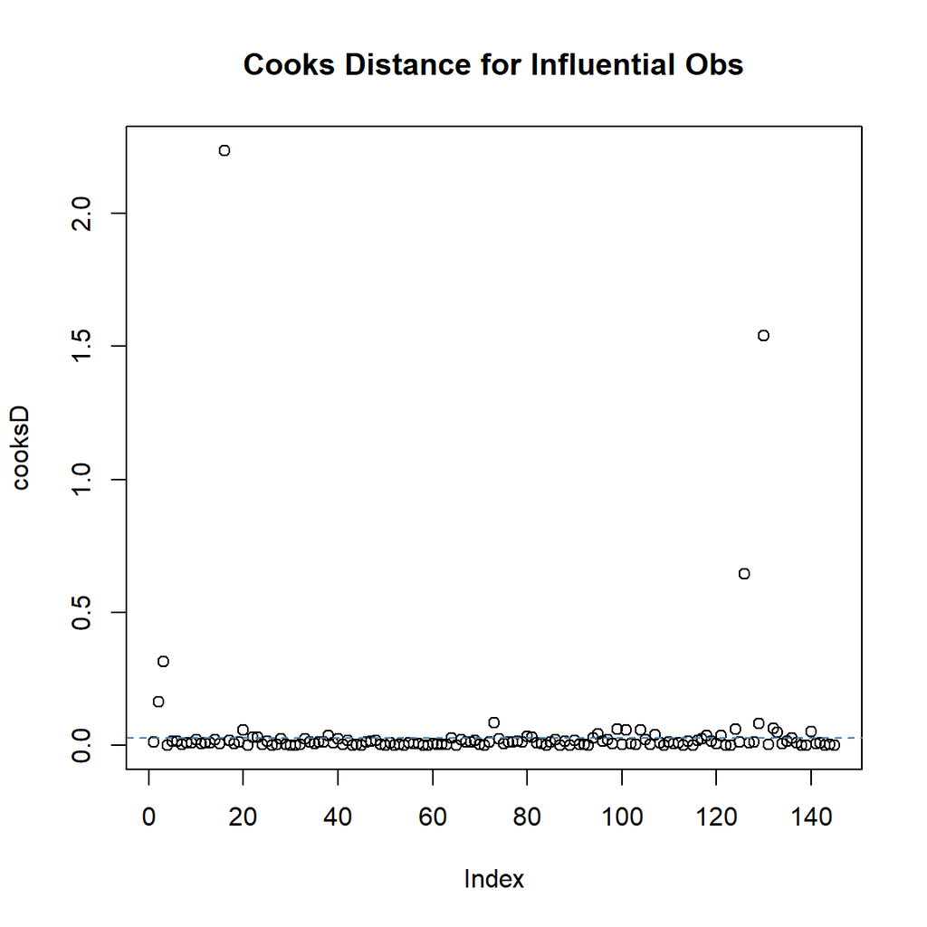

```r
cooksD = cooks.distance(mod2)
n <- nrow(dados_new)
plot(cooksD, main = "Cooks Distance for Influential Obs")
abline(h = 4/n, lty = 2, col = "steelblue") # Adicionar linha de corte
```

# REMOVENDO DADOS INFLUENTES

#### MODELO 3

## NOVO AJUSTE COM DADOS SEM PONTOS INFLUENTES

```r
dados_new1 <- dados_new[-influential_obs, ]

mod3 = glm( formula = IT ~ UE + CP + PEP , data = dados_new1 ,
           family = poisson(link = 'log') ,control=list(trace=TRUE))
```

```
## Deviance = 272.9848 Iterations - 1
## Deviance = 271.8174 Iterations - 2
## Deviance = 271.8173 Iterations - 3
## Deviance = 271.8173 Iterations - 4
```

```r
summary(mod3)
```

```
##
## Call:
## glm(formula = IT ~ UE + CP + PEP, family = poisson(link = "log"),
##     data = dados_new1, control = list(trace = TRUE))
##
## Deviance Residuals:
##     Min       1Q   Median       3Q      Max
## -2.7945  -1.1749  -0.2501   1.0624   3.7189
##
## Coefficients:
##               Estimate Std. Error z value Pr(>|z|)
## (Intercept)  4.185e+00  2.914e-02  143.62  < 2e-16 ***
## UE           7.246e-03  3.245e-04   22.33  < 2e-16 ***
## CP          -7.206e-03  3.041e-04  -23.70  < 2e-16 ***
## PEP          4.405e-04  7.093e-05    6.21 5.29e-10 ***
## ---
## Signif. codes:  0 '***' 0.001 '**' 0.01 '*' 0.05 '.' 0.1 ' ' 1
##
## (Dispersion parameter for poisson family taken to be 1)
##
##     Null deviance: 1125.37  on 120  degrees of freedom
## Residual deviance:  271.82  on 117  degrees of freedom
## AIC: 1093.2
##
## Number of Fisher Scoring iterations: 4
```

R2

```r
pR2(mod3)
```

```
## fitting null model for pseudo-r2
## Deviance = 1144.711 Iterations - 1
## Deviance = 1125.372 Iterations - 2
## Deviance = 1125.367 Iterations - 3
## Deviance = 1125.367 Iterations - 4
```

```
##          llh      llhNull           G2     McFadden         r2ML         r2CU
## -542.5769662 -969.3516324  853.5493324    0.4402682    0.9991362    0.9991363
```

### ANÁLISE DE RESÍDUO

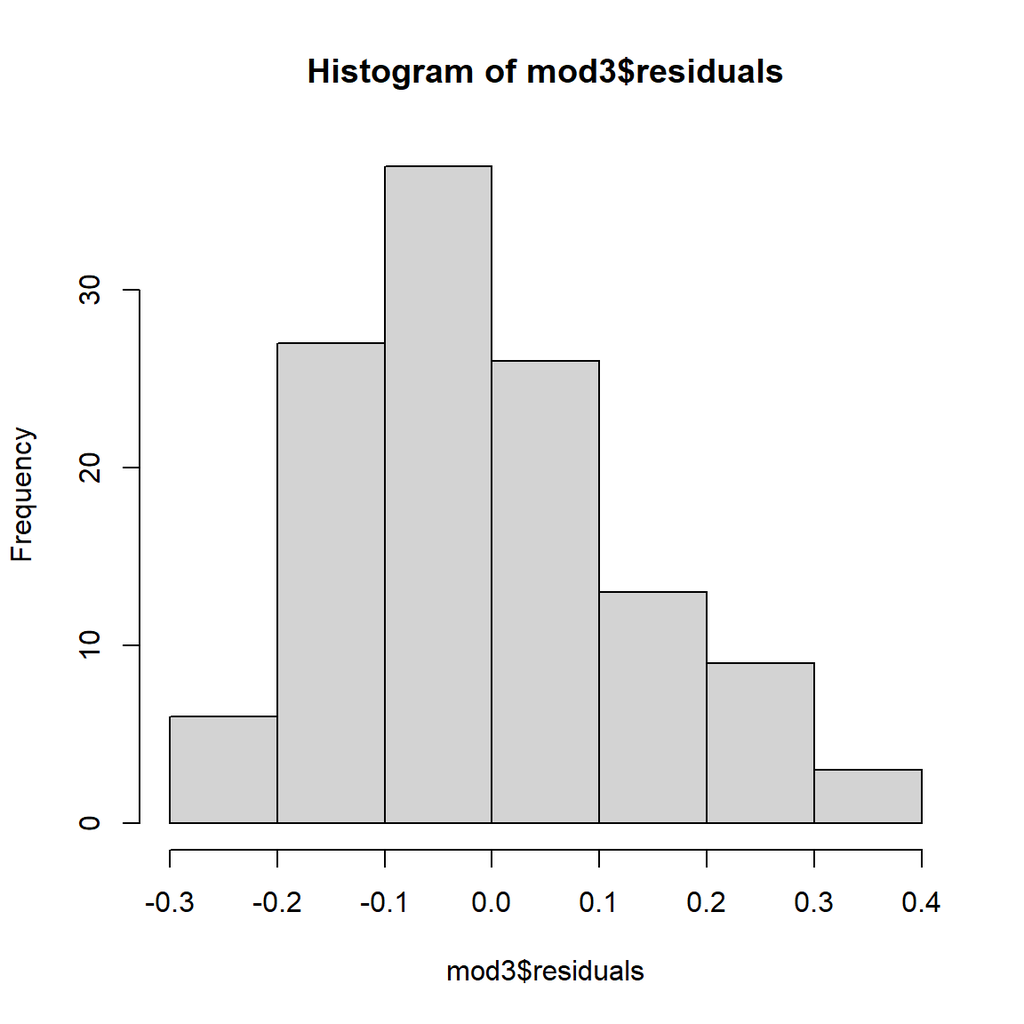

```r
hist( mod3$residuals )
```

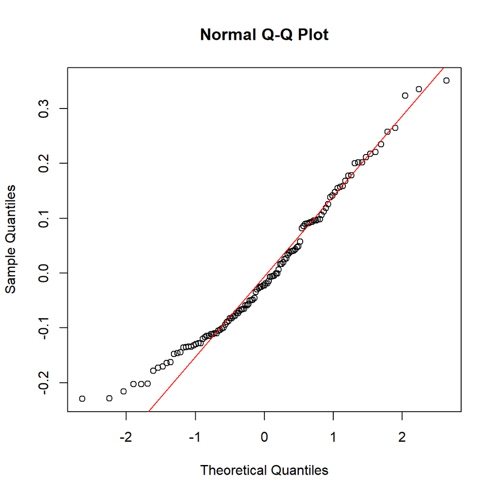

```r
qqnorm(mod3$residuals)
qqline( mod3$residuals, col = 'red' )
```

```r
shapiro.test( mod3$residuals )
```

```
##
##  Shapiro-Wilk normality test
##
## data:  mod3$residuals
## W = 0.96759, p-value = 0.005158
```

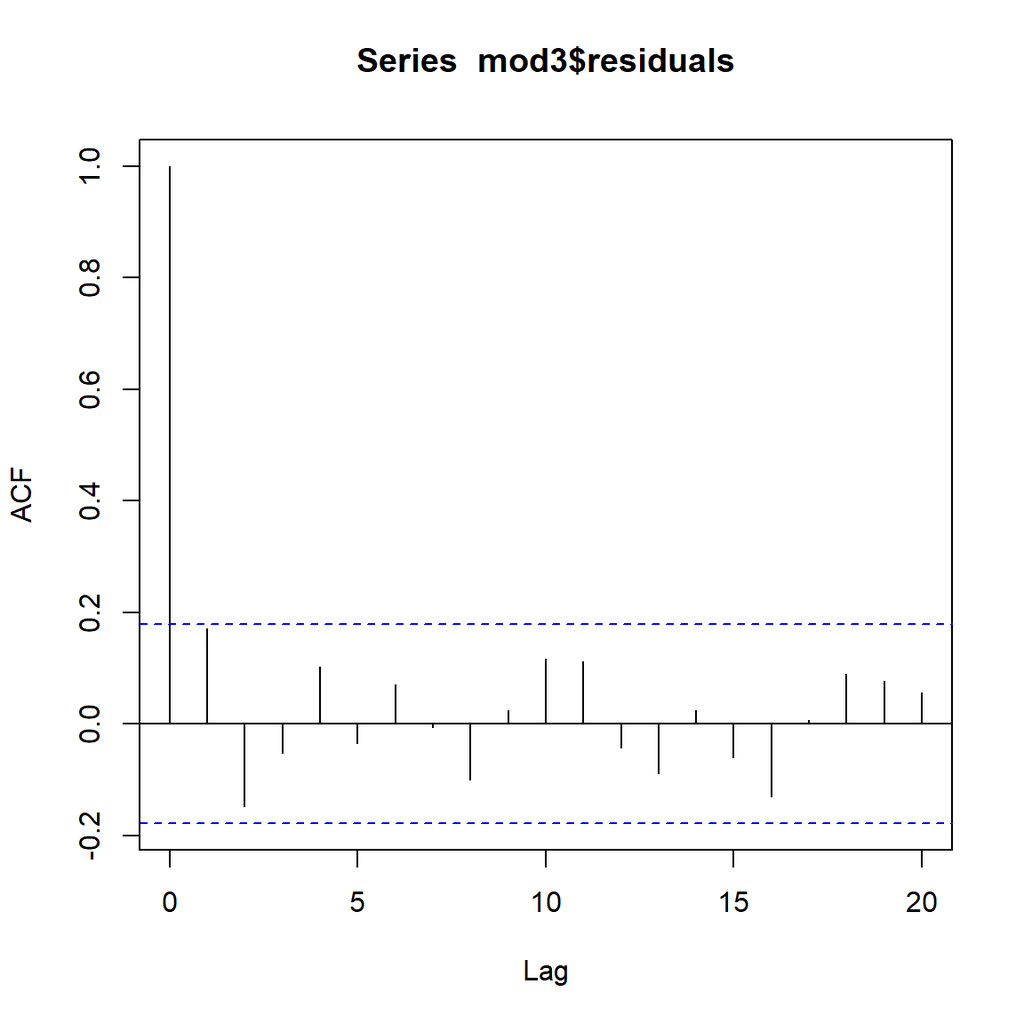

```r
acf(mod3$residuals)
```

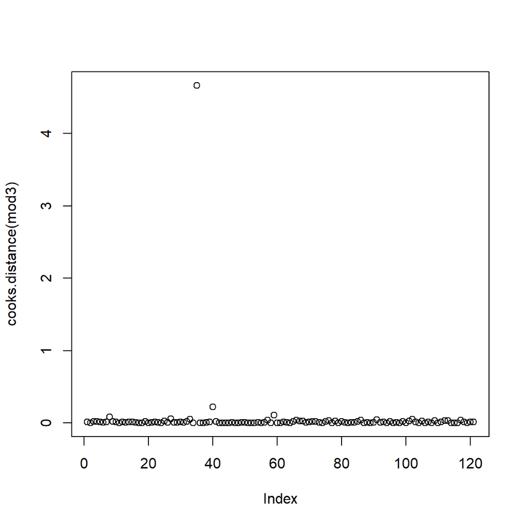

```r
plot(cooks.distance(mod3))
```

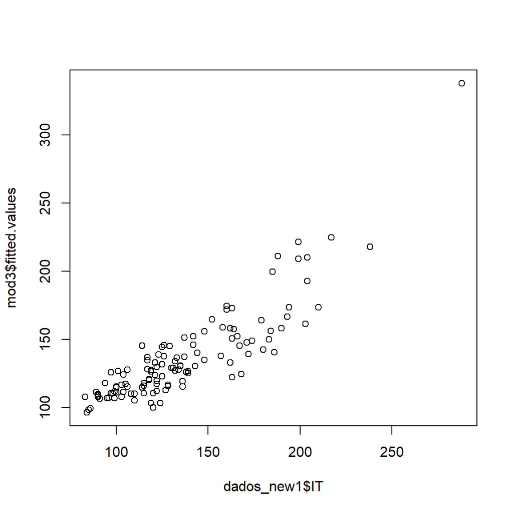

```r
plot(dados_new1$IT, mod3$fitted.values )
```

ANALISANDO AS VARIÁVEIS SIGNIFICATIVAS

```r
drop1(mod3, test = "Chi")
```

```
## Deviance = 761.1827 Iterations - 1
## Deviance = 752.5651 Iterations - 2
## Deviance = 752.564 Iterations - 3
## Deviance = 752.564 Iterations - 4
## Deviance = 821.5743 Iterations - 1
## Deviance = 811.5296 Iterations - 2
## Deviance = 811.5281 Iterations - 3
## Deviance = 811.5281 Iterations - 4
## Deviance = 312.0509 Iterations - 1
## Deviance = 310.5544 Iterations - 2
## Deviance = 310.5543 Iterations - 3
## Deviance = 310.5543 Iterations - 4
```

```
## Single term deletions
##
## Model:
## IT ~ UE + CP + PEP
##        Df Deviance    AIC    LRT  Pr(>Chi)
## <none>      271.82 1093.2
## UE      1   752.56 1571.9 480.75 < 2.2e-16 ***
## CP      1   811.53 1630.9 539.71 < 2.2e-16 ***
## PEP     1   310.55 1129.9  38.74 4.849e-10 ***
## ---
## Signif. codes:  0 '***' 0.001 '**' 0.01 '*' 0.05 '.' 0.1 ' ' 1
```

# COMPARANDO OS MODELOS

```r
Ajuste = c("Modelo ","Modelo 2","Modelo 3")
AIC = c(AIC(mod),AIC(mod2),AIC(mod3))
Deviance = c(deviance(mod),deviance(mod2),deviance(mod3))
Pseudo_R2 =c(rsq(mod),rsq(mod2),rsq(mod3))
```

```
## Deviance = 186724.3 Iterations - 1
## Deviance = 136978.6 Iterations - 2
## Deviance = 134014.2 Iterations - 3
## Deviance = 133997.3 Iterations - 4
## Deviance = 133997.3 Iterations - 5
## Deviance = 1862.134 Iterations - 1
## Deviance = 1822.171 Iterations - 2
## Deviance = 1822.153 Iterations - 3
## Deviance = 1822.153 Iterations - 4
## Deviance = 1144.711 Iterations - 1
## Deviance = 1125.372 Iterations - 2
## Deviance = 1125.367 Iterations - 3
## Deviance = 1125.367 Iterations - 4
```

```r
kable(data.frame(Ajuste, AIC, Deviance, Pseudo_R2))
```

| Ajuste | AIC | Deviance | Pseudo_R2 |
| --- | --- | --- | --- |
| Modelo | 50790.224 | 47501.2075 | 0.6341143 |
| Modelo 2 | 1497.578 | 503.5861 | 0.7256513 |
| Modelo 3 | 1093.154 | 271.8173 | 0.7601180 |